# Class 4 Lab 3

Spring 2022

## Class 4 Lab - Introduction to Thematic Mapping

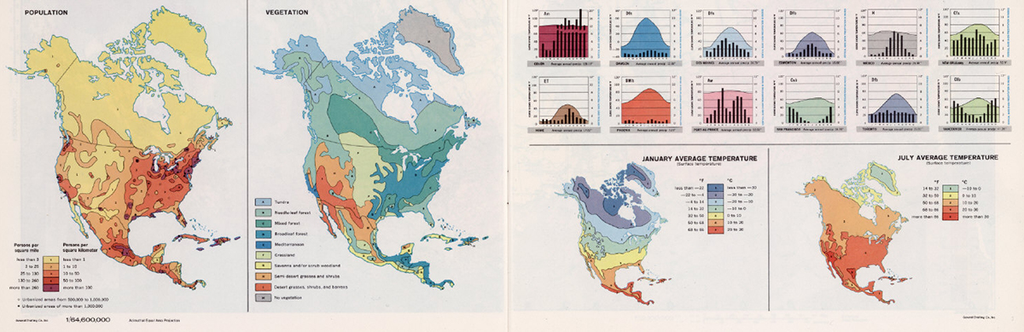

*source: https://www.davidrumsey.com/luna/servlet/detail/RUMSEY~8~1~243578~5513495:North-America-Thematic-Maps-*

### Concepts & Themes:

This week’s lab will feature exploration of the following:

- Classification methods
- Table Joins
- OTF (On the Fly) Projections
- Basic Statistics Tools

### Lab 4 Links:

During this week’s lab will utilize the following data & PDF guide:

- [Class 4 Lab PDF - Excercise 2+3 (Discover QGIS)](https://www.dropbox.com/s/ujvfc7htp93kwtc/c4.lab.pdf.zip?dl=1)
- [Class 4 Lab Data](https://www.dropbox.com/s/jqekvcf79tyrdhu/c4.lab.data.zip?dl=1)
  - `lab.4.partI.pdf`
  - `lab.4.partII.pdf`

### Lab Steps:

In this second lab, we will explore essentials of thematic mapping across quantitative data types. We will utilize 3 separate mappings - one for US Census data; one for US States. In this last mapping, the basic statistic tool will be utilized.

Some of the topics covered in this lab:

- Table joins
- OTF (On the Fly) Projections
- Classification Methods
- Histograms & Summary Statistics
- **To start**, download data needed for the lab from [Class 4 Lab Data](https://www.dropbox.com/s/jqekvcf79tyrdhu/c4.lab.data.zip?dl=1). Following the download, unzip the data and point QGIS to the data and secure a file path for the duration of the lab. Primary data download includes:
  - `countyp010` geometry
  - `ce2000t.dbf` tabular data
- Continue through Exercise 2 steps - `lab.4.partI.pdf` to complete a mapping of US Census data for county total population, lower 48 states (**Task 1** + **Task 2**).
- Once Exercise 2 mapping is complete, begin Exercise 3 - `lab.4.partII.pdf`. Primary data download includes:
  - `nm_counties.qgz` QGIS project loaded with New Mexico county geometries w/ `POP2000` column and `AVG_SALE87` column.
- working within **Task 5, 5.1 and 5.2**, Statistics and Histograms within QGIS will be explored for `POP2000` column and `AVG_SALE87` columns.

**No assignment deliverable is due for graded credit; this Lab is designed to orient and introduce the thematic mapping concepts and solutions to common thematic mapping challenges that will be useful for the graded Class 4 Assignment.**

### Further Reference:

- [Small Number Mapping example - heroin overdose per 100K population](https://www.odh.ohio.gov/-/media/ODH/ASSETS/Files/health/injury-prevention/2016-Ohio-Drug-Overdose-Report-FINAL.pdf?la=en)
- [Normalization Formulas for demographic data](http://web.mit.edu/11.188/www/labs/lab4/normalize_arcgis.pdf)